# Journal

Marshall Feldman

This is an [R Markdown](http://rmarkdown.rstudio.com) Notebook dedicated to taking notes about the data science associated with this project. It combines a daily log with topic-oriented notes.

# Importing Data

## *The real stuff begins just before 8/14/2021.*

## Getting Up to Speed

### 2021/08/12:

I started the project as a RStudio project and a private GitHub project. Initial data are kept in a LibreOffice Calc spreadsheet: Blood Pressure.ods. Then I tried to read it into R by using the [readODS package](https://cran.r-project.org/web/packages/readODS/index.html). I installed a bunch of packages, but unfortunately I did not keep track of all of them.

```r
library(datasets)
library("readODS")
library("rio")
install_formats()
```

```
[1] TRUE
```

```r
library("tsibble")
bp_ds <- read_ods(
  path = "../data/Blood Pressure.ods",
  sheet = "Export",
  skip = 2)
```

Note that here the path begins with “..” because this notebook is stored in ProjectTemplate’s “doc” folder and the data are stored in the “data” folder.

I then tried to fix this by renaming the data file from “Blood Pressure.ods” to “MMAF.ods”. I got the same results.

Then I snooped around the Internet and discovered the [rio package](https://cran.r-project.org/web/packages/rio/). Here I’ve moved **rio**’s **library** and **install_formats** statements to the previous chunk. I then used the following code, with the same results as before:

```r
convert("../data/Blood Pressure.ods", "../data/bp.rds")
```

```
Error in convert("../data/Blood Pressure.ods", "../data/bp.rds") :
  could not find function "convert"
```

and

```r
x <- import("../data/MMAF.ods")
```

```
Error: .onLoad failed in loadNamespace() for 'cli', details:
  call: fun(libname, pkgname)
  error: object 'clic_start_thread' not found
```

Frustrated, I posted a question on [stackoverflow](https://stackoverflow.com/questions/68766394/importing-from-a-libreoffice-calc-workbook), and Kat suggested viewing a post on “[Importing all sheets of an ODS file in R, keeping the name(s) of the sheets](https://stackoverflow.com/questions/61542069/importing-all-sheet-of-a-ods-file-in-r-keeping-the-name-of-the-sheets)”. I viewed it and went to bed.

### 2021/08/13:

I decided to replicate duckmayr’s example:

```r
library(readODS)
library(dplyr)
library(purrr)
library(tidyr)

path <- "../data/test.ods"

sheets <- ods_sheets(path)
```

```
ods_sheets will be depreciated in the next version. Use list_ods_sheets instead.
```

```r
mylist <- map(seq_along(sheets), read_ods, path = path) %>%
  set_names(sheets)
mylist
```

| a | b |
| --- | --- |
| 1 | 2 |
| 2 | 4 |

| a | b |
| --- | --- |
| 7 | 6 |
| 5 | 4 |

```
NA
```

But it still didn’t work. Eventually, I found [this advice](https://github.com/r-lib/devtools/issues/2224) and reinstalled the **cli** package (install.packages(“cli”)). This fixed things.

Based on the code above, here’s what I learned:

- **map** is in the [purrr package](https://purrr.tidyverse.org/), which provides functional programming tools
- **map** is one of a family of functions that do something for every element in a vector. **map** itself creates a list.
- Here **map** is used to apply **read_ods** to every worksheet in the test.ods file.

## The Real Import

Now let’s finally try to get the real data in.

## MODIFIED: 8/27/2021:

```r
library(datasets)
library("readODS")
library("rio")
library("tsibble")
library("dplyr")
library("tidyr")
library("ggplot2")
library("bp")
convert("../data/Blood Pressure.ods","../data/bp_data.rds", in_opts = list(sheet = "Export",  skip = 2))
bp_data <- readRDS("../data/bp_data.rds")
```

#TODO: (8/27/2021): Get the convert to work properly.

### 2021/08/14:

Finished the last chunk from yesterday.

## Process Data for *bp* Package

We now have a dataframe, **bp_data**, containing the blood pressure data. Now use the *process_data* function of the *bp* package to put it in the required format.

```r
bp_proc <- process_data(bp_data,
                        sbp = 'Systolic',
                        dbp = 'Diastolic',
                        bp_datetime = "DateTime",
                        hr = "Pulse"
                        )
```

```
No PP column found. Automatically generated from SBP and DBP columns.

No RPP column found. Automatically generated from SBP and HR columns.

No MAP column found. Automatically generated from SBP and DBP columns.

NOTE: Created DATE column from DATE_TIME column
```

```r
save(bp_proc, file = "../data/bp_proc.rds")
```

The messages in red are just warnings.

## 2011/08/17:

## Tidying the Data

Labeling the column for comments as “Comment(s)” was a bad idea. Earlier I fixed this in the Console, and here I’ll do it again just to illustrate how. I’ve already changed the column heading to “Comments,” and this should be the end of it.

```r
names(bp_data)[names(bp_data) == "Comment(s)"] <- "Comments"
# Do the same for bp_proc
names(bp_proc)[names(bp_proc) == "COMMENTS(S)"] <- "COMMENTS"
```

Also, most of the comments are blank, which means they are mapped to NA’s. Again, this is a bad idea; they should be blanks. Let’s fix this.

```r
bp_proc <- bp_proc %>%
  dplyr::mutate(COMMENTS = replace_na(COMMENTS, " "))
```

Finally, let’s delete the rows without data. This should fix the abrupt ending to the time series plot in the Visualizations section (p. 7).

```r
bp_proc <-
  bp_proc %>%
  drop_na()
```

## 2011/08/15:

# Analyzing Data

I followed the **Blood Pressure Metrics** section of the **bp** vignette, [bp: Blood Pressure Analysis in R.](https://cran.r-project.org/web/packages/bp/vignettes/bp.html)

### Blood Pressure Metrics

#### Average Real Variability (arv) vs Successive Variation (sv) pp. 5-6

```r
head(arv(bp_proc))
```

```
Missing SBP values found in data set. Removing for calculation
```

```
# A tibble: 1 × 4
     ID ARV_SBP ARV_DBP     N
  <dbl>   <dbl>   <dbl> <int>
1     1    9.22    6.70   129
```

```r
head(sv(bp_proc))
```

```
Missing SBP values found in data set. Removing for calculation
```

```
# A tibble: 1 × 4
     ID SV_SBP SV_DBP     N
  <dbl>  <dbl>  <dbl> <int>
1     1   11.5   8.46   129
```

These results make sense, but *I didn’t know how to make RStudio automatically display the expanded results as they appear in the console*.

**I fixed this with Chunk Settings > Use paged tables > off.**

Now let’s try the side-by-side version also on p. 5. The text suggests the analysis shows **arv** and **sv**, but the code uses cv instead of sv. Here are both results:

```r
head(dplyr::left_join(arv(bp_proc), sv(bp_proc)))
```

```
Missing SBP values found in data set. Removing for calculationMissing SBP values found in data set. Removing for calculationJoining, by = c("ID", "N")
```

```
# A tibble: 1 × 6
     ID ARV_SBP ARV_DBP     N SV_SBP SV_DBP
  <dbl>   <dbl>   <dbl> <int>  <dbl>  <dbl>
1     1    9.22    6.70   129   11.5   8.46
```

```r
head(dplyr::left_join(arv(bp_proc), cv(bp_proc)))
```

```
Missing SBP values found in data set. Removing for calculationMissing SBP values found in data set. Removing for calculationJoining, by = c("ID", "N")
```

```
# A tibble: 1 × 8
     ID ARV_SBP ARV_DBP     N CV_SBP CV_DBP SD_SBP SD_DBP
  <dbl>   <dbl>   <dbl> <int>  <dbl>  <dbl>  <dbl>  <dbl>
1     1    9.22    6.70   129   6.55   6.56   9.14   5.91
```

### TODO: Since I’m transitioning to the *tidyverse*, I need to learn what the *dplyr* function is doing.

The results above seem reasonable. SBP has larger magnitude than DBP, so it’s logical that measures of variance for SBP are larger too. The CV adjusts for magnitude by dividing the standard deviation by the mean. So CV’s for SBP & DBP are similar. In other words, other differences are due to the statistics used rather than much greater variation in one BP measurement versus the other. The difference between ARV and SV reflect the fact that SV is the sum of *squared differences,* while ARV is the sum of *absolute differences*. Hence, SV has larger magnitude. Because CV adjusts for magnitude by dividing by the mean, its values are <= than the absolute values used in ARV.

### Peaks and Troughs (p. 6)

```r
head(bp_mag(bp_proc))
```

```
Missing SBP values found in data set. Removing for calculation
```

```
# A tibble: 1 × 6
     ID Peak_SBP Peak_DBP Trough_SBP Trough_DBP     N
  <dbl>    <dbl>    <dbl>      <dbl>      <dbl> <int>
1     1     28.3     13.9       23.7       16.1   129
```

## Visualization

### Daily Variability

```r
viz_data <- bp_mag(bp_proc, inc_date = TRUE)
plot(viz_data[which(viz_data$Peak_SBP > 0 & viz_data$N > 1),]$DATE, viz_data[which(viz_data$Peak_SBP > 0 & viz_data$N > 1),]$Peak_SBP, type = 'l', col = "red", xlab = "DATE", ylab = "Magnitude")
lines(viz_data[which(viz_data$Peak_SBP > 0 & viz_data$N > 1),]$DATE, viz_data[which(viz_data$Trough_SBP > 0 & viz_data$N > 1),]$Trough_SBP, col = "darkgreen")
```

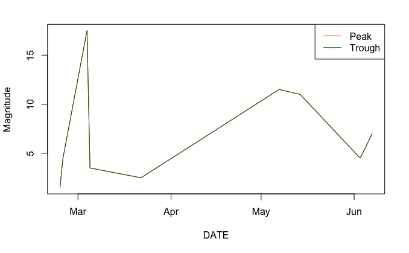

```r
legend("topright", legend = c("Peak", "Trough"), col = c("red", "darkgreen"), lty = 1)
```

Because there are usually only one observation per day, peaks and troughs are identical, and the green line prints over the red.

To investigate this, I entered **View(object)** in the console, where “object” is the object (either bp_data or bp_procI wanted to display. Both have **NA**’s where there are blanks in the spreadsheet.

**Solution!** The reason for the abrupt ending is *neither* due to missing data, *nor* a break in the sequence. The reason is because the plot selects cases for which Peak_SBP > 0, Trough_SBP > 0, and N > 1. It’s also because the plot is joining only the cases selected to be include in it. At the time of this writing, the last non-zero Peak_SBP and Trough_SBP occur on 2021/06/07; hence, everything after that is omitted from the plot.

Looking at the interior points, between 2021/02/23 and 2021/06/07, the selection eliminates those with magnitudes of zero. The plot then joins the points with magnitudes > 0.

If I had taken my blood pressure several times per day throughout the period, all the data points would have been included, and the graph would be much more meaningful.

### Categorizing SBP and DBP (p. 8)

This is very simple with the **bp** package.

[output not shown]

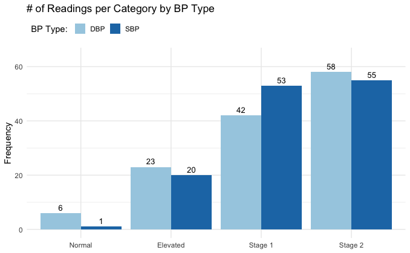

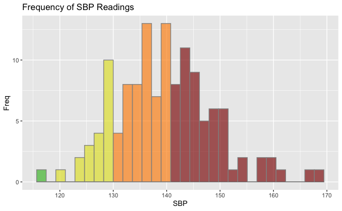

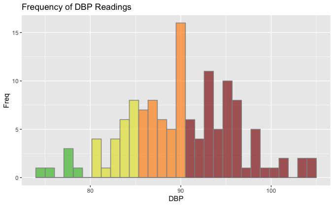

```r
bp_hist(bp_proc)
```

These results look grim, but at least they’re easy to obtain.

### Readings by Time of Day and Day of Week (pp. 8-9)

This uses the **bp** package’s *dow_tod_plots* function. As the vignette says, use the **girdExtra** package’s *grid_arrange* function to get the results in a grid.

```r
bptable_ex <- dow_tod_plots(bp_proc)
```

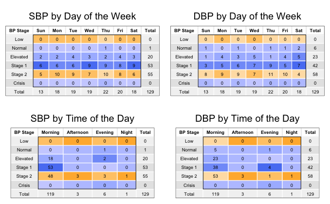

```r
gridExtra::grid.arrange(bptable_ex[[1]], bptable_ex[[2]], bptable_ex[[3]], bptable_ex[[4]], nrow = 2)
```

The time of day information is not very useful since I hardly ever took my blood pressure after noon. Unfortunately, the *dow_tod_plots* does not generate a legend that explains what the colors mean (if anything). Thursdays, Fridays, and Mondays are the worst days of the week. Coincidence?

### Summary Report (pp. 9 - 10)

This is also quite easy.

[output not shown]

[output not shown]

```
NA
```

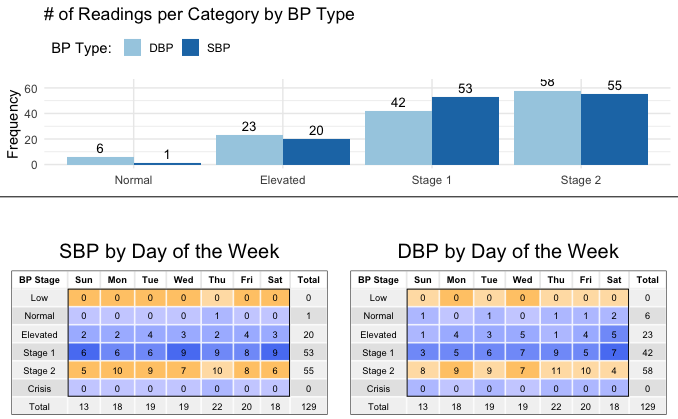

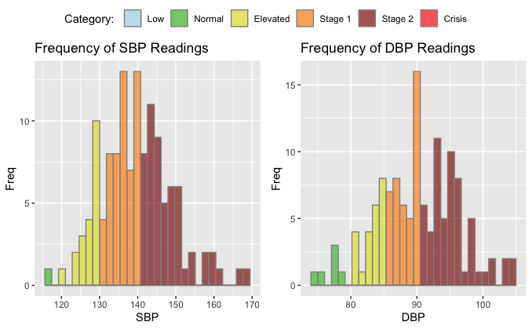

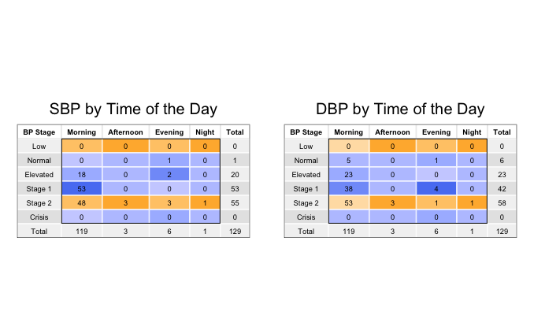

[figure not shown]

```r
bp_report(bp_proc)
```

Doing this in code chunks isn’t very nice. For now, it’s better to run it in the Console.

**TODO:** Find out how to make the code chunks prettier.

### Scatterplot Matrices

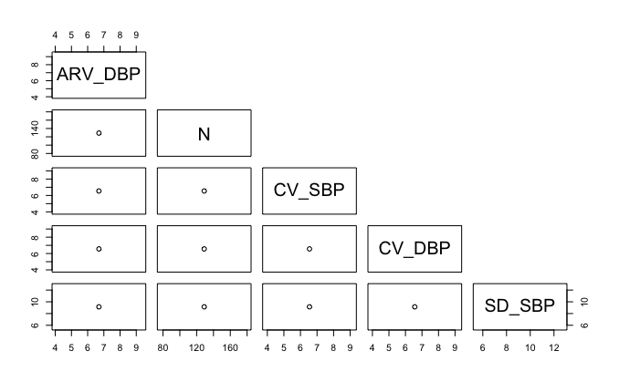

```r
viz_arv_cv <- dplyr::left_join(arv(bp_proc), cv(bp_proc))
pairs(viz_arv_cv[,4:ncol(viz_arv_cv)-1], upper.panel = NULL, col = factor(viz_arv_cv$ID))
```

The resulting plot has only one point. This is because **arv** and **cv** are summary statistics which, in this case, summarize only one ID.

The second matrix includes SBP, DBP, and HR plus three variables that are undefined in the vignette: MAP, PP, and RPP. As far as I can tell, they are:

**MAP**

**Mean Arterial Pressure**: The mean pressure through one cardiac cycle.

**PP**

**Pulse Pressure**: The difference between systolic and diastolic blood pressure.

**RPP**

**Rate Pressure Product**: Resting heart rate (RHR) multiplied by systolic blood pressure. A total value greater than 10,000 indicates increased risk for heart disease.

The matrix is obtained by:

```r
pairs(bp_proc[,6:11], upper.panel = NULL, col = factor(bp_proc$WAKE))
```

But this doesn’t work because, perhaps among other things, the Comments field is smack in the middle of the selected range and the other, generated variables are not in the 6:11 range.

```r
bp_proc <- bp_proc %>%
  relocate(COMMENTS, .after = "DBP_CATEGORY")
pairs(bp_proc[,3:8], upper.panel = NULL, col = factor(bp_proc$DAY_OF_WEEK))
```

[output not shown]

This version needed some changes from the vignette. First, **COMMENTS** is smack in the middle of the quantitative data range, so the **relocate** command moves **COMMENTS** to the last column. Second, the range of quantitative variables is 3:8 instead of 6:11, as in the vignette. Third, there is no **WAKE** variable in **bp_proc**, so I used **DAY_OF_WEEK** instead as a factor to color the point circles.

# Original Work

## Time Series

Since we’re migrating to the tidyverse, we’ll use tibbles and the tsibble package.

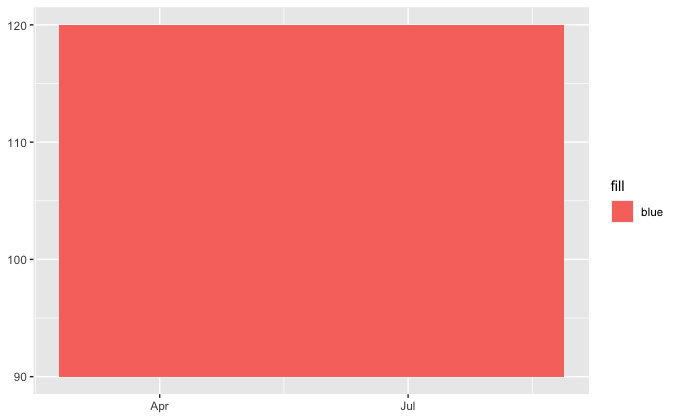

```r
library(tibble)
library(tsibble)
bp_tsbl <- bp_proc %>%
  as_tibble(index = DATE_TIME)

# Get the date range
first_date <- min(bp_tsbl$DATE)
last_date <- max(bp_tsbl$DATE)

# Start with the background colors for blood pressure levels
bp_colors <- c(Low = "lightblue",
               Normal = "#39ba25",
               Elevated = "#e3e029",
               `Stage 1` = "#ef8c00",
               `Stage 2` = "darkred",
               Crisis = "red")
# Now the ranges for the different kinds of reading
bp_ranges <- tribble(
  ~TYPE,     ~LABEL,      ~CATEGORY,   ~LOW,   ~HIGH,
  #-----|-------------|-------------|-------|--------
  "SBP",  "Systolic",        "Low",     80,      90,
  "SBP",  "Systolic",     "Normal",     90,     120,
  "SBP",  "Systolic",   "Elevated",    120,     129,
  "SBP",  "Systolic",    "Stage 1",    130,     139,
  "SBP",  "Systolic",    "Stage 2",    140,     179,
  "SBP",  "Systolic",     "Crisis",    180,     200,
  # See https://www.scienceabc.com/eyeopeners/how-high-can-a-blood-pressure-go.html
  "DBP", "Diastolic",        "Low",      0,      60,
  "DBP", "Diastolic",     "Normal",     60,      80,
  "DBP", "Diastolic",   "Elevated",     80,      80,
  "DBP", "Diastolic",    "Stage 1",     80,      89,
  "DBP", "Diastolic",    "Stage 2",     90,     119,
  "DBP", "Diastolic",     "Crisis",    120,     200
  # See https://www.scienceabc.com/eyeopeners/how-high-can-a-blood-pressure-go.html
)

# Now create the SBP & DBP templates.

# SBP
ranges <- filter(bp_ranges, TYPE == "SBP")
# SBP_template <-
  ggplot() +
  geom_rect(data = NULL,aes(
     xmin = first_date,
     xmax = last_date,
     ymin = filter(ranges, CATEGORY == "Normal")$LOW,
     ymax = filter(ranges, CATEGORY == "Normal")$HIGH,
             fill = "blue"))
```

```r
NA
NA
NA
NA
NA
NA
```